# Midwest survey using One-hot, CA, CA0, PCO, and Cerda methods

2023-05-23

### Midwest survey using One-hot, CA, CA0, PCO, and Cerda methods

#### 1. Load data

Midwest survey data from Cerda et al 2018.  
Survey to know if people self-identify as Midwesterners.  
Sample size: 2,778.  
Target variable (multiclass-clf): ‘Location (Census Region)’ (9 classes) - Cerda says 10 so perhaps includes missing, although they remove these rows anyway. Cerda selected categorical variable: ‘In your own words, what would you call the part of the country you live in now?’ (cardinality: 1,008) - again Cerda had extra one perhaps for missing.  
Other explanatory variables: ‘Personally identification as a Midwesterner?’ (4 levels, ordinal), ‘Gender’ (2 levels), ‘Age’ (4 levels, ordinal), ‘Household Income’ (5 levels, ordinal), ‘Education’ (5 levels, ordinal), ‘Illinois (IL) in the Midwest?’, ‘IN?’, ‘IA?’, ‘KS?’, ‘MI?’, ‘MN?’, ‘MO?’, ‘NE?’, ‘ND?’, ‘OH?’, ‘SD?’, ‘WI?’, ‘AR?’, ‘CO?’, ‘KY?’, ‘OK?’, ‘PA?’, ’WV?’, ’MT?’, ‘WY?’ (each of these last variables are indicator variables, although an individual can belong to more than one).

**Data preprocessing:**

– remove rows with missing values for the target variable or in any explanatory variable other than the selected categorical variable (reduces to 2421 observations);  
– for the selected categorical variable replace missing entries by the string ‘nan’;  
– transform all entries for the categorical variable to lower case;  
– convert all variables to ordinal, binary, or nominal factors.

Note that Cerda 2018 standardized every column of the feature matrix to a unit variance

**Calculate distance matrix** - Levenshtein distance “lv” (“hamming” only works when strings are the same length)

The categorical variables are either binary or ordinal apart from ‘categorical_variable’. Calculate a distance matrix for this variable only.

**Calculate PCO scores**

Only required for ‘categorical_variable’

Merge the data with the encoded categorical variable into a giant dataset (2421 x 2482)! The different methods will use different encodings of the categorical_variable column : Cerda method will use the 0 columns starting with “V”, PCO method will use the 0 columns starting with “PCO” (which captures 95% of the variation), CA and CA0 methods will use the uncoded categorical_variable column.

Because ranger will re-order the training and testing data independently, there is the chance of a certain level being converted to a different integer in each set. For unordered factors this happens when the order of first occurrence differs between the two data sets. It doesn’t seem to be a problem for ordered factors (the absent level will go right no matter where it is ordered). For PCO method can convert ordinal factors to numeric.

#### 2. Load methods

**Load libraries and functions**

**Define the data**

The different encoding methods will use different columns of data. The core variables will be used by all the methods, but the PCO method will use the numeric columns for the ordinal factors. CA, Binary, and CA_unbiased all use the same columns.

```r
core_vars <- midwest |> select(!where(is.numeric) & -categorical_variable & -respondent) |> colnames()
core_vars_numeric <- midwest |> select(!where(is.ordered) & !starts_with("V") & !starts_with("PCO") & -categorical_variable & -respondent) |> colnames()
```

Add a prefix to all the predictor variables names (so the functions can recognise the predictors).

```r
ca.dat <- midwest |> select(all_of(core_vars), categorical_variable) |> rename_with(.fn = function(.x){paste0("Var_", .x)}, .cols=-c(id, census_region))
pco.dat <- midwest |> select(all_of(core_vars_numeric), starts_with("PCO")) |> rename_with(.fn = function(.x){paste0("Var_", .x)}, .cols=-c(id, census_region))
cerda.dat <- midwest |> select(all_of(core_vars), starts_with("V")) |> rename_with(.fn = function(.x){paste0("Var_", .x)}, .cols=-c(id, census_region))
```

**Split data into training and test sets using folds**

```r
set.seed(3)
flds <- createFolds(y=midwest$census_region, k=10)
```

Merge into a single list of datasets and split into training and test sets

```r
list.of.data <- list(ca=ca.dat, binary=ca.dat, ca0=ca.dat, pco=pco.dat, cerda=cerda.dat)

list.of.train <- map(list.of.data,
                     function(x) {map(flds, ~slice(x, {-.}))})

list.of.test <- map(list.of.data,
                    function(x) {map(flds, ~slice(x, .))})
```

The CA_unbiased and binary methods will require the prepare_training step.  
The CA, PCO, and Cerda methods will use the transformed data straight into `ranger()`. Note that the ca method doesn’t allow for numeric columns or else we could just use the ca method on the transformed data.

Train the random forest models

```r
list.of.methods <- list(ca="raw", binary="binary",ca0="ca0", pco="raw",cerda="raw")

list.of.models <- pmap(list(list.of.train, list.of.test, list.of.methods),
     function(x, y, z) {
       map2(x, y, ~rf_model(.x, .y, method=z, class = "census_region", id="id", var_id="Var_", ntrees=1))
     })
```

Predict the test data and merge with true class

```r
list.of.forest_predictions <- map2(list.of.models, list.of.test, function(model, dat){  # list of 5 methods
  mod.list <- map(model, "ranger_mod")  # list of 10 ranger models
  prep.test.list <- map(model, "test")       # list of 10 prepared test sets
  class.list <- map(dat, function(x) x |> select("id", "census_region"))  # list of 10 dfs with id and class
  predictions.list <- pmap(list(mod.list, prep.test.list, class.list),
                           function(mod, prep.test, class) {
                             predictions <- predict(mod, prep.test)$predictions  #note predict.all = FALSE
                             bind_cols(class, prediction=predictions)}
                           )}
  )
```

Calculate the proportion of correct forest classifications (ie misclassification rate)

```r
list.of.forest_mc <- map(list.of.forest_predictions, function(x) {
    # merge the folds
    preds <- bind_rows(x, .id="fold")
    # weights for each fold
    w <- preds |> group_by(fold) |> tally() |> pull(n)
    # misclassification rates of the folds
    lm <- preds |> mutate(wrong = census_region != prediction) |>
      group_by(fold) |> summarise(mc = sum(wrong)/n()) |>
      lm(mc ~ 1, weights = w, data=_) |> summary()
    # weighted mean and standard error of the misclassification rates
    av <- coef(lm)[,"Estimate"]
    se <- coef(lm)[,"Std. Error"]
    # confusion matrix
    conf <- preds |> group_by(fold, census_region, prediction) |>
      summarise(n=n()) |> mutate(N=sum(n), p=n/sum(n)) |> ungroup() |>
      mutate(w = as.numeric(paste(factor(fold, labels=w))),
             t_p = paste(census_region, prediction, sep="_")) |>
      split(~t_p)
    # weighted mean and standard error of the confusion matrices
    conf.lm <- map(conf, function(x) {lm(p~1, weights=w, data=x) |> summary()})
    conf.av <- map(conf.lm, function(x) coef(x)[,"Estimate"])
    conf.se <- map(conf.lm, function(x) coef(x)[,"Std. Error"])
    out <- list(av=av, se=se, conf.av=conf.av, conf.se=conf.se)
    out})

#list.of.forest_mc |> map(pluck("av"))
#list.of.forest_mc |> map(pluck("se"))
```

Pull out individual tree decisions for each observation,  
identify observations with unique levels in the testing data,  
and calculate misclassification rates of the individual trees according to the use of absent levels

```r
list.of.tree_predictions <- map2(list.of.models, list.of.test, function(model, dat){
  mod.list <- map(model, "ranger_mod")
  train.list <- map(model, "train")
  prep.test.list <- map(model, "test")
  test.list <- dat
  class.list <- map(model, "class")
  id.list <- map(model, "id")
  predictions.list <- pmap(list(mod.list, train.list, prep.test.list, class.list, id.list, test.list),
    function(mod, train, prep.test, class, id, test) {
      uniques <- is_unique(data=test, list_of_extras=train$extra)
      tree_preds <- predict_by_tree(mod=mod, new_data=prep.test, new_unique=uniques, id=id)
      tree_preds |> left_join(test |> select(id, any_of(class)), by="id")}
    )}
  )

list.of.tree_mc <- map(list.of.tree_predictions, function(x){
  x |> bind_rows() |>
    mutate(uses_unique = if_else(uses_unique == 0, "No", "Yes")) |>
    group_by(uses_unique, census_region, prediction) |>
    summarise(n=n()) |>
    group_by(uses_unique, census_region) |>
    mutate(N = sum(n)) |>
    mutate(prop = n/N)
})
```

### It still doesn’t seem correct?

… the forest misclassification rates are only kind of matching the tree misclassification rates.

```
## $ca
## # A tibble: 9 × 5
##   census_region      prediction         tree.absent tree.no.absent forest
##   <chr>              <chr>                    <dbl>          <dbl>  <dbl>
## 1 East.North.Central East.North.Central      0.792           0.701  0.716
## 2 West.North.Central West.North.Central      0.327           0.476  0.454
## 3 New.England        New.England             0.143           0.16   0.196
## 4 Mountain           Mountain                0.140           0.269  0.229
## 5 East.South.Central East.South.Central      0.08            0.103  0.163
## 6 South.Atlantic     South.Atlantic          0.0615          0.180  0.164
## 7 West.South.Central West.South.Central      0.0612          0.161  0.148
## 8 Pacific            Pacific                 0.0351          0.275  0.217
## 9 Middle.Atlantic    Middle.Atlantic        NA               0.419  0.318
##
## $binary
## # A tibble: 9 × 5
##   census_region      prediction         tree.absent tree.no.absent forest
##   <chr>              <chr>                    <dbl>          <dbl>  <dbl>
## 1 East.North.Central East.North.Central      0.597          0.740  0.711
## 2 West.North.Central West.North.Central      0.299          0.416  0.394
## 3 Middle.Atlantic    Middle.Atlantic         0.227          0.398  0.348
## 4 Pacific            Pacific                 0.181          0.240  0.221
## 5 Mountain           Mountain                0.149          0.186  0.171
## 6 South.Atlantic     South.Atlantic          0.148          0.237  0.206
## 7 West.South.Central West.South.Central      0.111          0.0865 0.0966
## 8 New.England        New.England             0.0667         0.122  0.159
## 9 East.South.Central East.South.Central     NA              0.0635 0.144
##
## $ca0
## # A tibble: 9 × 5
##   census_region      prediction         tree.absent tree.no.absent forest
##   <chr>              <chr>                    <dbl>          <dbl>  <dbl>
## 1 West.North.Central West.North.Central      0.309           0.529  0.494
## 2 West.South.Central West.South.Central      0.217           0.178  0.192
## 3 Mountain           Mountain                0.182           0.273  0.240
## 4 East.South.Central East.South.Central      0.143           0.123  0.161
## 5 South.Atlantic     South.Atlantic          0.137           0.226  0.198
## 6 New.England        New.England             0.133           0.189  0.200
## 7 Middle.Atlantic    Middle.Atlantic         0.0889          0.450  0.351
## 8 Pacific            Pacific                 0.0714          0.367  0.281
```

[output cut: 14 more lines]

```
## 9 East.South.Central East.South.Central       0.133          0.190  0.193
##
## $cerda
## # A tibble: 9 × 5
##   census_region      prediction         tree.absent tree.no.absent forest
##   <chr>              <chr>                    <dbl>          <dbl>  <dbl>
## 1 Pacific            Pacific                  0.5            0.628  0.620
## 2 East.North.Central East.North.Central       0.385          0.707  0.696
## 3 New.England        New.England              0.333          0.547  0.539
## 4 West.North.Central West.North.Central       0.231          0.388  0.382
## 5 Middle.Atlantic    Middle.Atlantic          0.143          0.590  0.561
## 6 West.South.Central West.South.Central       0.143          0.320  0.305
## 7 East.South.Central East.South.Central       0.125          0.153  0.166
## 8 Mountain           Mountain                 0.125          0.550  0.512
## 9 South.Atlantic     South.Atlantic           0.125          0.428  0.418
```

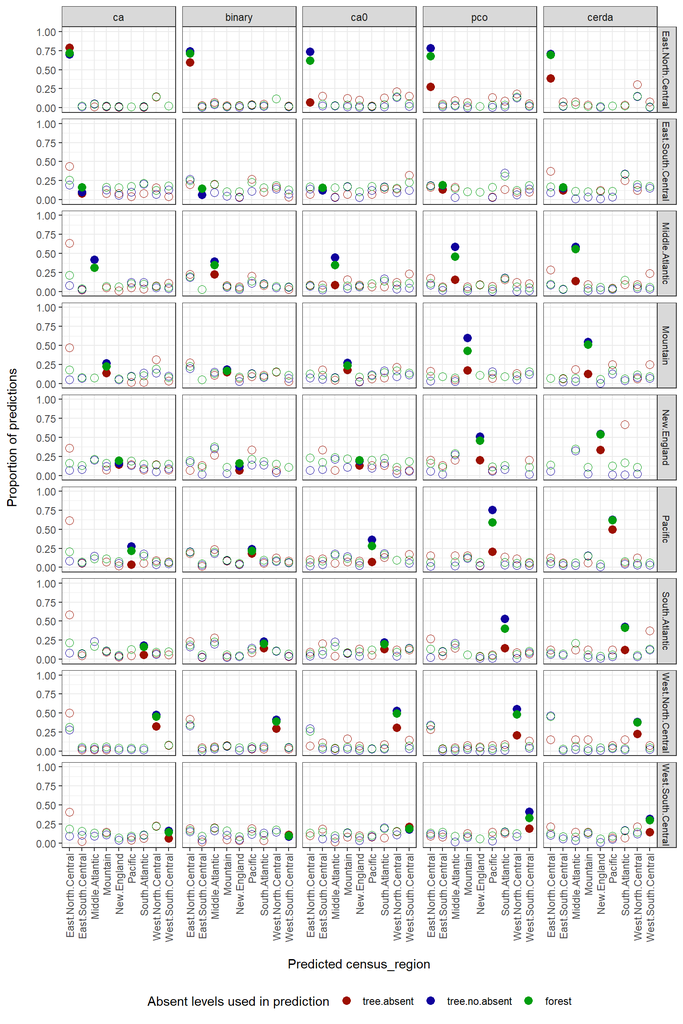